# Minería de Datos

Clase 6: Tipos de Datos y Estructuras

Departamento de Estadística, Sede Bogotá

## ¿Dónde estamos en el proceso KDD?

**Clase 1**

KDD · CRISP-DM  
¿Qué es minería de datos?

Conceptual

→

**Clases 2–3**

Web scraping  
CSV · JSON · HTML

Adquisición

→

**Clases 4–5**

SQL · JOINs  
CTEs · Ventanas

Consulta

→

**Clase 6 — Hoy**

Tipos · Estructuras  
Alta dimensionalidad

Representación

**Hilo conductor:** ya sabemos *cómo obtener* datos. Esta clase responde: ¿qué **forma** tienen esos datos y cómo **representarlos** para que un algoritmo de minería pueda procesarlos?

## Contenido de la clase

Parte I

Tipos de datos

- Estructurados
- Semi-estructurados
- No estructurados

Define el preprocesamiento necesario

Parte II

Estructuras de datos

- DataFrames
- Matrices densas y dispersas
- Grafos
- Tensores

Define qué algoritmos son posibles

Parte III

Alta dimensionalidad

- Maldición de la dimensionalidad
- Sparsity
- Reducción de dimensión

Define si las distancias aún sirven

## Tipos de datos

## Taxonomía general

Estructurados

**Esquema fijo**: filas y columnas con tipos definidos. Directamente consultables con SQL y Listos para análisis estadístico.

CSV SQL Excel

Semi-estructurados

Jerarquía y etiquetas, pero sin esquema tabular rígido. La estructura varía entre registros. Requieren parseo.

JSON XML HTML

No estructurados

Sin formato predefinido. Requieren *feature engineering* para convertirse en representación numérica que los algoritmos puedan consumir.

Texto Imagen Audio

Se estima que entre el **80% y 90%** de los datos generados en el mundo son no estructurados (estimación comúnmente citada en la industria; IDC, 2020). La frontera activa de la minería de datos está en extraer información de ellos.

## Datos estructurados

#### Características

- Esquema explícito: cada columna tiene nombre y tipo fijo.
- Almacenables en sistemas relacionales (las bases Chinook de clases 4–5).
- Consultables directamente con SQL (`SELECT`, `JOIN`, `GROUP BY`).
- Representables como DataFrame o matriz sin transformación intermedia.

#### Ejemplos

- **Tabla de clientes:** Columnas: ID, nombre, correo, fecha de registro.
- **Inventario:** Columnas: producto, stock disponible, proveedor, categoría.
- **Datos de sensores:** Columnas: timestamp, temperatura, humedad, presión.
- **Supersalud:** reclamaciones y prestaciones en bases relacionales.

## Datos semi-estructurados: JSON y XML

#### JSON: JavaScript Object Notation

```json
{
  "municipio": "Bogotá",
  "vigencia": 2023,
  "indicadores": [
    {"nombre": "homicidios", "valor": 12.4},
    {"nombre": "hurtos",     "valor": 847.1}
  ]
}
```

Formato estándar de APIs web. Ya lo obtuvimos con web scraping en clases 2–3.

#### XML: eXtensible Markup Language

```xml
<municipio codigo="11001">
  <nombre>Bogotá D.C.</nombre>
  <departamento>Cundinamarca</departamento>
  <poblacion>7412566</poblacion>
</municipio>
```

Presente en sistemas gubernamentales, DIAN (factura electrónica), intercambio de datos IGAC.

**Reto para DM:** un registro JSON puede tener campos ausentes, listas anidadas de longitud variable o sub-objetos. El proceso de *aplanado* (flattening) a tibble es un paso de preprocesamiento crítico.

## Datos no estructurados

#### Tipos frecuentes

- **Texto:** noticias, redes sociales, reseñas de productos, informes médicos.
- **Imágenes:** radiografías, fotos satelitales, capturas de formularios escaneados.
- **Audio:** llamadas de call center, grabaciones de juzgados.
- **Video:** cámaras de tránsito, grabaciones de consultas médicas.

#### Ruta hacia la representación numérica

Dato crudo (texto, imagen, audio)

↓ Feature engineering

Representación numérica (TF-IDF, embeddings, HOG, MFCC)

↓ Conversión

Matriz dispersa / densa → algoritmo de DM

Este proceso introduce **alta dimensionalidad**: un texto de 500 palabras sobre vocabulario de 50.000 términos produce un vector de 50.000 dimensiones. Esto conecta con la Parte III.

## Tabla comparativa

| Característica | Estructurado | Semi-estructurado | No estructurado |
| --- | --- | --- | --- |
| **Esquema fijo** | ✅ Sí | ⚠️ Parcial / variable | ❌ No |
| **Consulta con SQL** | ✅ Directa | ⚠️ Con funciones JSON/XML | ❌ No directamente |
| **Listo para algoritmos** | ✅ Sí (tras encoding) | ⚠️ Tras aplanado | ❌ Requiere feature engineering |
| **Ejemplos en Colombia** | DANE GEIH, Registraduría | APIs datos.gov.co | Tweets, radiografías, audio de llamadas |
| **Volumen típico** | Moderado | Grande | Muy grande |

## Ejemplo: JSON de datos abiertos → tibble

Parsear y aplanar un JSON con estructura jerárquica (simulando datos.gov.co)

```r
library(jsonlite)
library(dplyr)
library(tibble)

json_datos <- '
[
  {"municipio": "Bogotá", "año": 2022,
   "indicadores": {"desempleo": 11.2, "pobreza": 32.1}},
  {"municipio": "Medellín", "año": 2022,
   "indicadores": {"desempleo": 9.8, "pobreza": 28.4}},
  {"municipio": "Cali", "año": 2022,
   "indicadores": {"desempleo": 13.5, "pobreza": 36.7}},
  {"municipio": "Barranquilla", "año": 2022,
   "indicadores": {"desempleo": 10.1, "pobreza": 30.2}}
]'

datos_raw <- fromJSON(json_datos)
```

```r
datos_tbl <- as_tibble(datos_raw) |>
  mutate(
    desempleo = indicadores$desempleo,
    pobreza = indicadores$pobreza
  ) |>
  select(-indicadores)
```

```
Estructura del JSON parseado:
```

```
'data.frame':   4 obs. of  3 variables:
 $ municipio  : chr  "Bogotá" "Medellín" "Cali" "Barranquilla"
 $ año        : int  2022 2022 2022 2022
 $ indicadores:'data.frame':    4 obs. of  2 variables:
  ..$ desempleo: num  11.2 9.8 13.5 10.1
  ..$ pobreza  : num  32.1 28.4 36.7 30.2
```

```
# A tibble: 4 × 4
  municipio      año desempleo pobreza
  <chr>        <int>     <dbl>   <dbl>
1 Bogotá        2022      11.2    32.1
2 Medellín      2022       9.8    28.4
3 Cali          2022      13.5    36.7
4 Barranquilla  2022      10.1    30.2
```

## Estructuras de datos

## La estructura determina el algoritmo

Cada algoritmo espera sus datos en una **representación específica**. Elegir mal la estructura significa usar el algoritmo equivocado o no poder usarlo.

📊 Regresión lineal / logística

Matriz $X \in \mathbb{R}^{n \times p}$

Necesita columnas numéricas homogéneas. Regresión lineal minimiza $\|y - X\beta\|^2$; logística maximiza la verosimilitud vía gradiente. Ambas requieren $X$ numérica y sin NA.

🔵 K-Means / K-NN

Matriz de atributos $X \in \mathbb{R}^{n \times p}$

Parten de la matriz de atributos y computan distancias internamente. K-NN busca vecinos por $d_{ij}=\|x_i-x_j\|$; K-Means actualiza centroides sobre $X$. Si $p$ es grande, la concentración de distancias invalida el resultado — Parte III.

🕸️ PageRank / GNN

Grafo $G = (V, E)$

La información está en las *relaciones* entre nodos, no en atributos de filas. Una tabla pierde esa topología.

## DataFrame

#### Propiedades

- Cada columna es un vector homogéneo de tipo fijo (numérico, carácter, factor, fecha).
- El conjunto de columnas puede ser **heterogéneo**: mezcla tipos en la misma tabla.
- Operaciones de alto nivel: filtrado, agrupación, unión (`join`), pivoteo — ya vistos con `dplyr` y SQL.
- No es directamente consumible por la mayoría de algoritmos de ML: primero hay que **convertirlo a matriz numérica**.

#### Variantes en R

| Tipo | Uso recomendado |
| --- | --- |
| `data.frame` | Base R, compatibilidad máxima |
| `tibble` | Tidyverse, análisis cotidiano |
| `data.table` | Datos grandes (>1M filas), modificación por referencia |

`tibble$col_inexistente` devuelve `NULL` con advertencia; `data.frame` hace *partial matching* sin avisar — fuente de bugs silenciosos.

## DataFrame

```r
# Vista de los datos
titanic |>
  select(survived,
         pclass,
         sex,
         age,
         fare,
         embarked) |>
  head(4)
```

```
# A tibble: 4 × 6
  survived pclass sex      age   fare embarked
     <dbl>  <dbl> <chr>  <dbl>  <dbl> <chr>
1        0      1 male      38 153.   S
2        0      3 male      33  20.5  S
3        1      1 female    24 263    S
4        0      3 female    14   7.85 S
```

```r
# data.table — misma operación
tit_dt <- titanic |>
          as.data.table()
tit_dt[, .(survived,
           pclass,
           sex,
           age,
           fare,
           embarked)][1:4]
```

```
   survived pclass    sex   age     fare embarked
      <num>  <num> <char> <num>    <num>   <char>
1:        0      1   male    38 153.4625        S
2:        0      3   male    33  20.5250        S
3:        1      1 female    24 263.0000        S
4:        0      3 female    14   7.8542        S
```

## Matrices

#### Matriz densa $X \in \mathbb{R}^{n \times p}$

Todos los elementos se almacenan explícitamente. Apropiada cuando la mayoría de valores son distintos de cero.

- **Matriz de diseño:** $n$ observaciones × $p$ predictores es la entrada de regresión, SVM, PCA.
- **Matriz de correlaciones/covarianzas:** $p \times p$ es la base del análisis multivariado.
- **Matriz de distancias:** $n \times n$ requerida por K-NN, clustering jerárquico.

Acceso O(1) Memoria O(n·p)

#### Matriz dispersa (*sparse*)

Solo se almacenan los valores **distintos de cero** junto con sus coordenadas (fila, columna). Esencial cuando la densidad de datos es baja.

- **Matriz documento-término (DTM):** 10.000 docs × 50.000 palabras → 99.9% ceros.
- **Matriz usuario-producto:** cada usuario califica un pequeño subconjunto de ítems.

Memoria O(nnz) Sin acceso O(1) por índice

DTM densa: 10k × 50k × 8 bytes ≈ **4 GB**. DTM dispersa: < **40 MB**.

## Matriz numérica

```r
# Paso 1: separar predictores (X) de variable respuesta (y)
datos_modelo <- titanic |>
  select(survived, pclass, age, fare, sibsp, parch) |>
  na.omit()

y <- datos_modelo$survived          # vector respuesta — fuera de X
X <- datos_modelo |>
  select(-survived) |>
  as.matrix()
```

```
Dimensiones X: 1045 5 | Tipo: matrix array | Memoria: 41.6 Kb
```

```
     pclass age   fare sibsp parch
[1,]      1  38 153.46     0     1
[2,]      3  33  20.52     1     1
[3,]      1  24 263.00     3     2
[4,]      3  14   7.85     0     0
```

```r
# Paso 2: centrar y escalar antes de X'X (requerido para PCA)
X_scaled <- scale(X)
# Diagonal de X'X escalada ≈ (n-1) por variable estandarizada
XtX <- crossprod(X_scaled)
```

```r
round(diag(XtX))   # cada valor ≈ n - 1 si la variable está normalizada
```

```
pclass    age   fare  sibsp  parch
  1044   1044   1044   1044   1044
```

#### ¿Qué habilita?

- **Regresión lineal:** $\hat{\beta} = (X^TX)^{-1}X^Ty$
- **PCA:** descomposición de $\Sigma = \frac{1}{n-1}X^TX$
- **K-NN:** distancia euclidiana $d_{ij} = \|x_i - x_j\|$
- **SVM:** producto interno $K(x_i, x_j) = x_i \cdot x_j$

**Condiciones previas**: Solo columnas numéricas, Sin NA y Escalar si las unidades difieren (`scale()`).

## Matriz dispersa

```r
library(Matrix)
# Simular DTM: 1.000 docs × 5.000 palabras (~0.1% no-ceros, como una DTM real)
dtm_densa  <- matrix(rpois(1000 * 5000, 0.001), nrow = 1000)
dtm_sparse <- Matrix(dtm_densa, sparse = TRUE)
```

```
Dimensiones: 1000 5000 | Densa: 19.1 Mb | Dispersa: 0.1 Mb | Densidad: 0.1 % no-cero | Ahorro: 240
```

```r
# Estructura interna CSC (dgCMatrix): solo almacena (col, fila, valor)
str(dtm_sparse)
```

```
Formal class 'dgCMatrix' [package "Matrix"] with 6 slots
  ..@ i       : int [1:5151] 557 101 183 824 28 248 933 179 868 990 ...
  ..@ p       : int [1:5001] 0 1 1 2 4 4 6 7 10 10 ...
  ..@ Dim     : int [1:2] 1000 5000
  ..@ Dimnames:List of 2
  .. ..$ : NULL
  .. ..$ : NULL
  ..@ x       : num [1:5151] 1 1 1 1 1 1 1 1 1 1 ...
  ..@ factors : list()
```

#### ¿Cuándo es obligatorio?

- **NLP:** documento × vocabulario → 99% ceros.
- **Recomendación:** usuario × ítem (Netflix, Spotify).
- **Genómica (scRNA-seq):** muestra × gen — en secuenciación de célula única la mayoría de genes no se expresan.

## Grafos

#### ¿Qué es un grafo?

$G = (V, E)$: conjunto de **nodos** $V$ (entidades) y **aristas** $E$ (relaciones). Captura información que una tabla pierde: las *conexiones* entre observaciones son el dato relevante.

| No dirigido | Red de coautoría, amistad. |
| --- | --- |
| Dirigido | Seguimiento en redes sociales, citas académicas. |
| Bipartito | Usuarios y productos en e-commerce. |
| Ponderado | Monto de transacciones, rutas de transporte. |

#### Aplicaciones en minería de datos

- Detección de comunidades: ¿quiénes forman grupos naturales en la red de egresados de la UNAL?
- Detección de fraude: transacciones como aristas ponderadas entre cuentas.
- Sistemas de recomendación: proyección bipartita usuario-ítem.
- PageRank: nodos = páginas, aristas = hiperenlaces — base del buscador de Google.

En R: paquetes `igraph` y `tidygraph`. En Python: `networkx`.

## Grafos: Red de aeropuertos colombianos

```r
library(igraph); library(dplyr); library(readr)

# Aeropuertos colombianos con código IATA válido
airports <- read_csv("../../data/airports.csv", show_col_types = FALSE)
colombia <- airports |>
  filter(Country == "Colombia", nchar(IATA) == 3, IATA != "\\N") |>
  transmute(iata = IATA, ciudad = City,
            lat = Latitude, lon = Longitude)

# Distancia haversine (km) entre dos coordenadas
haversine <- function(la1, lo1, la2, lo2) {
  r <- pi / 180; R <- 6371
  a <- sin((la2-la1)*r/2)^2 +
       cos(la1*r)*cos(la2*r)*sin((lo2-lo1)*r/2)^2
  2 * R * asin(sqrt(a))
}

# Aristas: pares de aeropuertos a < 900 km
n <- nrow(colombia)
pares <- expand.grid(i = seq_len(n), j = seq_len(n)) |>
  filter(i < j) |>
  mutate(
    from = colombia$iata[i], to = colombia$iata[j],
    km   = round(mapply(haversine,
             colombia$lat[i], colombia$lon[i],
             colombia$lat[j], colombia$lon[j]))
  ) |>
  filter(km < 900)

# Construir grafo
G_col <- graph_from_data_frame(
  d        = pares[, c("from","to","km")],
  directed = FALSE,
  vertices = colombia |> rename(name = iata)
)
```

```
── Grafo completo (< 900 km) ──
```

```
Aeropuertos (nodos) : 69
```

```
Conexiones (aristas): 1885
```

```
Densidad de red     : 0.803
```

```
Más conectado       : BOG — Bogota (grado 65 )
```

#### Paquetes en R

| `igraph` | Construcción, análisis, plot base |
| --- | --- |
| `tidygraph` | API tidy (`activate(nodes/edges)`) |
| `ggraph` | Visualización con gramática ggplot2 |

Una tabla plana de atributos **no captura por sí sola la topología** de las relaciones: un grafo sí lo hace de forma nativa.

[figure not shown]

## Tensores

Un **tensor** generaliza el concepto de matriz a cualquier número de dimensiones (órdenes). Es la estructura nativa de las redes neuronales y el aprendizaje profundo.

Escalar

Orden 0 — $\mathbb{R}$

Un número: temperatura, precio, edad.  
`42.5`

Vector

Orden 1 $\mathbb{R}^{p}$

Una observación con $p$ variables.  
`c(38, 1, 153.5)`

Matriz

Orden 2 $\mathbb{R}^{n \times p}$

$n$ observaciones × $p$ variables.  
La matriz de diseño $X$.

Tensor

Orden $k$ $\mathbb{R}^{d_1 \times \cdots \times d_k}$

3 o más dimensiones: imágenes, video, series temporales.

**En R:** `array(datos, dim = c(d₁, d₂, …, dₖ))`. Una matriz es un tensor de orden 2; un vector es un tensor de orden 1.

**En DM:** los tensores son la unidad de datos de las redes neuronales (PyTorch, TensorFlow). El pipeline es: *DataFrame → Matriz → Tensor*.

## Tensores

Imágenes (CNN)

Tensor $\mathbb{R}^{N \times H \times W \times C}$

$N$ imágenes, $H$ alto, $W$ ancho, $C$ canales (RGB = 3). Una radiografía 512×512 en escala de grises: $\mathbb{R}^{N \times 512 \times 512 \times 1}$.

keras torch

Series temporales

Tensor $\mathbb{R}^{N \times T \times F}$

$N$ series, $T$ pasos de tiempo, $F$ variables por paso. Datos de panel: 32 ciudades × 12 meses × 5 indicadores.

forecast torch

NLP (Transformer)

Tensor $\mathbb{R}^{N \times L \times d}$

$N$ textos, $L$ tokens por oración, $d$ dimensión del embedding. BERT usa $d = 768$.

text torch

**Maldición de la dimensionalidad:** un lote de 100 imágenes RGB de 64×64 px ocupa $100 \times 64 \times 64 \times 3 = 1{.}228{.}800$ valores. Escalar a 512×512 lo multiplica por 64×. La estructura *tensor* más operaciones eficientes (convolución) son la respuesta.

## Tensores

```r
# Tensor 3D: 32 ciudades × 12 meses × 5 indicadores
n_ciudades    <- 32L; n_meses <- 12L; n_ind <- 5L
panel <- array(
  rnorm(n_ciudades * n_meses * n_ind, mean = 50, sd = 10),
  dim      = c(n_ciudades, n_meses, n_ind),
  dimnames = list(
    ciudad     = paste0("C", sprintf("%02d", seq_len(n_ciudades))),
    mes        = month.abb,
    indicador  = c("PIB","Desempleo","Inflación","Exportaciones","Pobreza")
  )
)
```

```
Dimensiones: 32 12 5 | Memoria: 19 Kb
```

```
  Jan   Feb   Mar   Apr   May   Jun   Jul   Aug   Sep   Oct   Nov   Dec
51.58 43.99 61.98 34.36 48.97 51.85 53.72 46.71 52.55 54.88 58.02 31.94
```

```
      indicador
ciudad   PIB Desempleo Inflación Exportaciones Pobreza
   C01 63.13     53.72     38.74         53.83   48.15
   C02 70.30     47.02     51.05         38.80   39.89
   C03 45.09     56.55     51.46         63.71   42.70
   C04 44.92     66.32     58.05         41.74   51.26
```

```
          PIB     Desempleo     Inflación Exportaciones       Pobreza
        50.45         50.07         50.58         49.99         50.79
```

#### Anatomía del tensor

| 1.ª dim | Ciudad (32), unidad de observación |
| --- | --- |
| 2.ª dim | Mes (12), tiempo |
| 3.ª dim | Indicador (5), variable |

#### Operaciones clave

- `array[i, , ]`, todas las mediciones de la ciudad *i*
- `apply(T, 3, mean)`, media por indicador

**Conexión:** este tensor 3D se aplana a una matriz 2D antes de entrar a regresión o clustering — operación llamada *unfolding* o *matricización*.

## Problemas de Alta Dimensionalidad

## ¿Qué es dimensionalidad?

**Definición**

La **dimensionalidad** de un conjunto de datos es el número de variables $p$ que describen cada observación. Con $n$ observaciones, los datos viven en $\mathbb{R}^p$. El régimen de **alta dimensionalidad** ocurre cuando $p$ es grande relativo a $n$, o cuando $p \to \infty$.

Genómica

$n$ = 200 pacientes  
$p$ = 20.000+ genes  
$p \gg n$

NLP / Texto

$n$ = 5.000 tweets  
$p$ = 50.000 palabras únicas  
99% de entradas = 0

Imágenes

Imagen 256×256 px = 65.536 variables por observación

## La maldición de la dimensionalidad

**Bellman (1961)**

La expresión **“curse of dimensionality”** describe cómo ciertos problemas computacionales y estadísticos se vuelven intratables a medida que $p$ crece. No es solo un problema de cómputo: es un problema geométrico fundamental.

#### Intuición geométrica: el hipercubo

En un hipercubo unitario de $p$ dimensiones, para capturar una fracción $r$ del volumen se necesita un sub-cubo de lado:

$$\ell = r^{1/p}$$

- $p=10$: $\ell = 0.79$ — el 79% de cada dimensión.
- $p=100$: $\ell = 0.977$ — casi todo el espacio.

*Capturar el *mismo vecindario local* en alta dimensión requiere barrer casi todo el espacio, los “vecinos” ya no son locales.*

#### Consecuencias estadísticas

- Se necesitan exponencialmente más observaciones para mantener la misma densidad muestral.
- Los estimadores no paramétricos (K-NN, kernel density) pierden consistencia.
- La varianza del estimador crece con $p$: mayor riesgo de **sobreajuste**.
- Todas las distancias se vuelven similares entre sí — los algoritmos basados en distancias pierden poder discriminativo.

## Concentración de distancias

#### El resultado formal

Para puntos aleatorios $\mathbf{x}, \mathbf{y} \sim U[0,1]^p$, la razón entre la distancia máxima y la mínima converge a 1:

$$\frac{d_{\max} - d_{\min}}{d_{\min}} \xrightarrow{p \to \infty} 0$$

En dimensión alta, el punto más cercano y el más lejano están casi a la misma distancia. La noción de **“vecino cercano”** pierde significado.

**Impacto directo:** K-NN, clustering por K-Means, SVM con kernel RBF y cualquier algoritmo que use distancias euclidianas se degrada en alta dimensión.

#### ¿Por qué ocurre?

La distancia euclidiana acumula varianza de *p* coordenadas:

$$d(\mathbf{x}, \mathbf{y}) = \sqrt{\sum_{j=1}^{p}(x_j - y_j)^2}$$

Por la ley de grandes números, cuando $p \to \infty$:
$$\frac{d(\mathbf{x}, \mathbf{y})}{\sqrt{p}} \xrightarrow{p \to \infty} \sigma_d \quad \text{(constante)}$$

Todas las distancias se concentran alrededor del mismo valor: la variabilidad relativa desaparece.

## Demostración: distancias en alta dimensión

```r
set.seed(2024)
dimensiones <- c(1, 2, 5, 10, 50, 100, 500, 1000)

resumen <- sapply(dimensiones, function(p) {
  puntos <- matrix(runif(500 * p), nrow = 500, ncol = p)
  dists  <- sapply(1:200, function(i)
    sqrt(sum((puntos[i, ] - puntos[i + 200, ])^2)))
  c(media = mean(dists), cv = sd(dists) / mean(dists))
})

data.frame(
  p          = dimensiones,
  dist_media = round(resumen["media", ], 4),
  cv_pct     = round(resumen["cv", ] * 100, 2)   # coeficiente de variación
)
```

```
     p dist_media cv_pct
1    1     0.3517  72.81
2    2     0.4923  49.17
3    5     0.8898  28.38
4   10     1.2672  19.77
5   50     2.8595   8.34
6  100     4.0849   6.20
7  500     9.1127   2.57
8 1000    12.9016   1.82
```

**Observación:** el coeficiente de variación (CV) de las distancias cae sostenidamente con $p$. En $p = 1000$, todas las distancias son casi idénticas, un algoritmo K-NN no puede distinguir vecinos de extraños.

## Sparsity: consecuencia natural de la alta dimensionalidad

#### ¿Qué es sparsity?

Un conjunto de datos es **disperso** cuando la gran mayoría de sus valores son cero o están ausentes. Es la consecuencia práctica de trabajar en espacios de alta dimensión.

- **Texto:** un documento de 300 palabras únicas sobre vocabulario de 80.000 → 99.6% ceros.
- **Recomendación:** un usuario califica 40 de 10.000 películas → 99.6% sin valorar.
- **Genómica (scRNA-seq):** en secuenciación de célula única la gran mayoría de genes no se expresan por célula.

#### Implicaciones para minería de datos

- Almacenar todos los ceros es ineficiente: usar `Matrix::sparseMatrix` (R) o `scipy.sparse` (Python), ahorro de 100x en memoria.
- La distancia euclidiana falla: usar distancia coseno o Jaccard, diseñadas para vectores dispersos.
- Los algoritmos deben poder operar sobre matrices CSR/CSC sin materializar la versión densa.

**Conexión:** la Parte II mostró la diferencia de memoria entre DTM densa (GB) y dispersa (MB). Ahora entendemos *por qué* ese problema existe.

## Estrategias ante la alta dimensionalidad

#### Selección de variables

Eliminar variables irrelevantes o redundantes *antes* del modelado.

- **Filtro:** varianza, correlación, prueba $\chi^2$, información mutua.
- **Wrapper:** selección hacia adelante / atrás usando un modelo como criterio.
- **Embedded:** LASSO penaliza coeficientes a cero implícitamente.

#### Reducción de dimensionalidad

Proyectar los datos a un espacio de menor dimensión preservando la información relevante.

- **PCA:** proyección lineal que maximiza varianza explicada.
- **t-SNE / UMAP:** proyección no lineal, útil para visualización.
- **Autoencoders:** reducción con redes neuronales.

#### Regularización

Penalizar la complejidad del modelo para evitar sobreajuste cuando $p$ es grande relativo a $n$.

- **Ridge ($L_2$):** reduce la magnitud de todos los coeficientes.
- **LASSO ($L_1$):** fuerza coeficientes a exactamente cero — selección implícita.

## Ejemplo

¿Por qué reducir? — Proyección de datos iris de 4 a 2 dimensiones

```r
library(ggplot2)

pca      <- prcomp(iris[, 1:4], scale. = TRUE)
var_expl <- pca$sdev^2 / sum(pca$sdev^2)
```

```
Varianza explicada: PC1=73.0%, PC2=22.9%, acumulada=95.8%
```

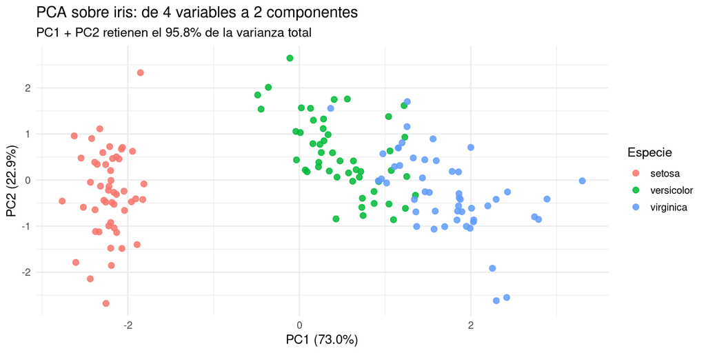

## Síntesis: los tres temas conectados

Fuente de datos  
*JSON, CSV, SQL, texto*

→

Tipo de dato  
*¿Estructurado?*

→

Estructura en memoria  
*DataFrame / Matriz / Grafo*

→

¿Alta dimensión?  
*Reducir / Seleccionar*

→

Algoritmo de DM

**Tipo** determina cuánto preprocesamiento se necesita antes de construir la estructura analítica.

**Estructura** determina qué operaciones y algoritmos son posibles computacionalmente.

**Dimensionalidad** determina qué estrategias de reducción o regularización son necesarias antes del modelado.

**Ejercicio 1: clasificación de tipos de datos**

Para cada fuente de datos, indique: (a) si es estructurada, semi-estructurada o no estructurada; (b) la razón; (c) el paso de preprocesamiento mínimo para convertirla en un tibble analizable.

1. Microdatos GEIH del DANE (archivo `.csv` de 300.000 filas)
2. Respuesta JSON de la API pública `datos.gov.co` con indicadores de calidad del aire
3. Grabaciones de audio de audiencias judiciales de la Rama Judicial
4. Factura electrónica emitida por la DIAN (formato XML)
5. Tabla HTML de Wikipedia scrapeada con `rvest` en las clases 2–3

**Ejercicio 2: JSON anidado a DataFrame**

Descargue el siguiente JSON público con datos de usuarios (incluye campos anidados `address` y `company`):

```r
library(jsonlite); library(dplyr); library(tibble)
url  <- "https://jsonplaceholder.typicode.com/users"
raw  <- fromJSON(url)
```

1. Explore la estructura con `str(raw)`. ¿Qué columnas son listas anidadas?
2. Aplane el objeto a un tibble con una fila por usuario, extrayendo al menos: `name`, `email`, `address.city`, `address.geo.lat`, `address.geo.lng` y `company.name`.
3. ¿Qué tipo de dato es esta fuente? ¿Por qué `fromJSON` no produce directamente un tibble plano?

**Ejercicio 3: matriz de diseño**

Con `titanic.csv` y las variables `age`, `fare`, `sibsp`, `parch` (elimine NA):

1. Construya $X$ centrada y escalada con `scale()`. Reporte sus dimensiones y la memoria que ocupa.
2. Calcule $X^TX$. ¿Qué representa la diagonal cuando $X$ está escalada?
3. Construya la versión dispersa con `Matrix(X, sparse = TRUE)`. Compare el tamaño en memoria con `object.size()`. ¿Tiene sentido usar formato disperso aquí?
4. ¿Qué estructura de datos usaría para modelar las relaciones familiares entre pasajeros (`sibsp`, `parch`)? Justifique.

**Ejercicio 4: concentración de distancias**

Replique la demostración de la clase para $p \in \{1, 2, 5, 10, 50, 100, 500, 1000, 5000\}$ (use `set.seed(42)`):

1. Para cada $p$, genere 500 puntos uniformes en $[0,1]^p$ y calcule 200 distancias euclidianas entre pares. Reporte la distancia media y el coeficiente de variación (CV).
2. Grafique distancia media y CV vs. $p$ (escala log en $x$) con `ggplot2`.
3. ¿A partir de qué $p$ el CV cae por debajo del 5%? ¿Qué implica esto para K-NN?
4. Repita el punto 1 usando **distancia coseno** en lugar de euclidiana. ¿Se concentra igual de rápido?

**Ejercicio 5: PCA y reducción de dimensionalidad**

Con las variables numéricas del Titanic escaladas (`age`, `fare`, `sibsp`, `parch`, `pclass`):

1. Aplique PCA con `prcomp(..., scale. = TRUE)`. ¿Cuántos componentes son necesarios para retener ≥ 80% de la varianza? ¿Y para ≥ 95%?
2. Grafique el *scree plot* (varianza acumulada vs. número de componente) con `ggplot2`.
3. Examine los *loadings* de PC1 y PC2. ¿Qué variables dominan cada componente? Proponga una interpretación en el contexto del Titanic.
4. **Reto:** aplique K-Means ($k = 2$) sobre $X$ original y sobre los 2 primeros PCs por separado. Compare los grupos resultantes con la variable `survived`. ¿En cuál representación los grupos coinciden mejor con la supervivencia?